# Get started

## Introduction

```r
# Load all libraries for this example
library(INLAvaan)
library(tidyverse)
library(lavaan)
```

## Motivating example

To motivate the use of SEMs, consider the introductory example in Song and Lee (2012): *Does poorer glycemic control lead to greater severity of kidney disease?* We observe three indicators of glycemic control (*y*<sub>1</sub>, *y*<sub>2</sub>, *y*<sub>3</sub>) and three indicators of kidney disease severity (*y*<sub>4</sub>, *y*<sub>5</sub>, *y*<sub>6</sub>).

|  | **Indicator** | **Description** | **Unit** |
| --- | --- | --- | --- |
| *y*<sub>1</sub> | HbA1c | 3-month avg. blood glucose | % |
| *y*<sub>2</sub> | FPG | Fasting plasma glucose | mmol/L |
| *y*<sub>3</sub> | Insulin | Fasting insulin level | μU/mL |
| *y*<sub>4</sub> | PCr | Plasma creatinine | μmol/L |
| *y*<sub>5</sub> | ACR | Albumin–creatinine ratio | mg/g |
| *y*<sub>6</sub> | BUN | Blood urea nitrogen | mmol/L |

Rather than fitting separate regression models for each indicator, SEM allows us to model the relationship between the latent constructs themselves, providing a clearer and more coherent representation of the underlying processes. The hypothesised SEM is illustrated by the figure below:

[figure not shown]

## Data

For the two-factor SEM we described above, it is easy to simulate some data using the `{lavaan}` package to do so. The code is below:

```r
pop_mod <- "
  eta1 =~ 1*y1 + 0.8*y2 + 0.6*y3
  eta2 =~ 1*y4 + 0.8*y5 + 0.6*y6
  eta2 ~ 0.3*eta1

  # Variances
  y1 ~~ 0.5*y1
  y2 ~~ 0.5*y2
  y3 ~~ 0.5*y3
  y4 ~~ 0.5*y4
  y5 ~~ 0.5*y5
  y6 ~~ 0.5*y6
  eta1 ~~ 1*eta1
  eta2 ~~ 1*eta2
"
set.seed(123)
dat <- lavaan::simulateData(pop_mod, sample.nobs = 1000)
str(dat)
```

```
#> 'data.frame':    1000 obs. of  6 variables:
#>  $ y1: num  0.238 0.532 0.575 -0.179 3.318 ...
#>  $ y2: num  0.0152 0.5357 1.123 1.0083 1.2431 ...
#>  $ y3: num  0.547 0.382 1.875 -0.52 -0.42 ...
#>  $ y4: num  -1.369 -0.599 1.072 0.884 -0.966 ...
#>  $ y5: num  -0.702 -1.472 1.575 -0.793 -1.165 ...
#>  $ y6: num  -0.73 -0.026 1.051 -0.477 -1.945 ...
```

From the code above, note the true values of the parameters, including the factor loadings *Λ*, regression coefficient *β* between the two latent variables, as well as the residual and latent variances *Θ* and *Ψ* respectively.

## Model fit

Now that we have simulated some data, we can fit the SEM using INLAvaan. The model syntax is similar to that of `{lavaan}`, making it easy to specify the model. For further details on the model syntax, refer to the [lavaan website](https://lavaan.ugent.be/tutorial/syntax1.html). `{INLAvaan}` provides mirror functions for the main model fitting functions in `{lavaan}`:

- `acfa()` mirrors `lavaan::cfa()` for confirmatory factor analysis; and
- `asem()` mirrors `lavaan::sem()` for structural equation models;
- `agrowth()` mirrors `lavaan::growth()` for latent growth curve models.

The code to fit the SEM model is below:

```r
mod <- "
  eta1 =~ y1 + y2 + y3
  eta2 =~ y4 + y5 + y6
  eta2 ~ eta1
"
fit <- asem(mod, dat)
```

```
#> ℹ Mode finding and Hessian computation.
#> ✔ Posterior mode and Hessian. [91ms]
#>
#> ℹ Performing VB correction.
#> ✔ VB correction; mean |δ| = 0.043σ. [70ms]
#>
#> ⠙ Fitting 0/13 skew-normal marginals.
#> ✔ Fit 13/13 skew-normal marginals. [130ms]
#>
#> ⠙ Posterior sampling and summarising.
#> ✔ Summarise 1000 posterior draws. [173ms]
#>
#> ℹ Fit measures: PPP, DIC.
```

As with `lavaan::sem()`, this model is fitted without a mean structure by default (`meanstructure = FALSE`). Rather than profiling the means out as lavaan does, `{INLAvaan}` assigns the saturated means flat priors and marginalises them analytically, which keeps the likelihood a proper Bayesian object. Intercepts can instead be modelled explicitly with `meanstructure = TRUE`. See the [mean structures article](https://inlavaan.haziqj.ml/articles/meanstructure.html) for how the two treatments relate and when model comparisons across them are meaningful.

`{INLAvaan}` computes an approximation to the posterior density by way of a Laplace approximation (Tierney et al. 1989; Jamil and Rue 2026a). The joint mode and the Hessian needs to be computed, which gives a Gaussian distribution for the joint posterior of the parameters. The default method for optimisation is `stats::nlminb()`, but other optimisers can be used by specifying `optim_method = "ucminf"` for the `{ucminf}` package or `optim_method = "optim"` to call the `stats::optim()` function with method `"BFGS"`.

From this, marginal posterior distributions for each parameter can be obtained by one of several ways, including 1) Skew normal fitting (`marginal_method = "skewnorm"`, the default method, see Chiuchiolo et al. 2023); 2) Two-piece asymmetric Gaussian fitting (`marginal_method = "asymgaus"`, see Martins et al. 2013); 3) Direct marginalisation of the joint Gaussian posterior (`marginal_method = "marggaus"`); and 4) Sampling from the joint Gaussian posterior (`marginal_method = "sampling"`).

Once the marginal posterior distributions have been obtained, we can further use these to compute any derived quantities of interest via copula sampling. The posterior predictive p-values (Gelman et al. 1996) and Deviance Information Criterion (DIC, Spiegelhalter et al. 2002) are computed this way. The `test` argument names which of these post-estimation quantities to compute: the default `test = "standard"` computes the PPP and the DIC, `test = "full"` adds the leave-one-out cross-validation and WAIC results (see the model comparison section below) and stores them with the fit, and `test = "none"` skips them all. Often, the posterior sampling takes longer than the model fitting itself, so the number of samples can be controlled via the `nsamp` argument (default is `nsamp = 1000`).

## Methods

The resulting object is of class `INLAvaan`, a subclass of `lavaan` objects.

```r
str(fit, 1)
```

```
#> Formal class 'INLAvaan' [package "INLAvaan"] with 21 slots
```

```r
fit
```

```
#> INLAvaan 0.3.2 ended normally after 64 iterations
#>
#>   Estimator                                      BAYES
#>   Optimization method                           NLMINB
#>   Number of model parameters                        13
#>
#>   Number of observations                          1000
#>
#> Model Test (User Model):
#>
#>    Marginal log-likelihood                   -8084.295
#>    PPP (Chi-square)                              0.327
```

As a result, most of the methods that work for `lavaan` objects will also work for `INLAvaan` objects. The most common ones are probably `coef()` and `summary()`.

```r
# Inspect coefficients
coef(fit)
```

```
#>   eta1=~y2   eta1=~y3   eta2=~y5   eta2=~y6  eta2~eta1     y1~~y1     y2~~y2
#>      0.802      0.598      0.833      0.652      0.283      0.509      0.456
#>     y3~~y3     y4~~y4     y5~~y5     y6~~y6 eta1~~eta1 eta2~~eta2
#>      0.518      0.459      0.494      0.506      0.897      1.068
```

```r
# Summary of results
summary(fit)
```

```
#> INLAvaan 0.3.2 ended normally after 64 iterations
#>
#>   Estimator                                      BAYES
#>   Optimization method                           NLMINB
#>   Number of model parameters                        13
#>
#>   Number of observations                          1000
#>
#> Model Test (User Model):
#>
#>    Marginal log-likelihood                   -8084.295
#>    PPP (Chi-square)                              0.327
#>
#> Information Criteria:
#>
#>    Deviance (DIC)                            16063.280
#>    Effective parameters (pD)                    13.072
#>
#> Parameter Estimates:
#>
#>    Marginalisation method                     SKEWNORM
#>    VB correction                                  TRUE
#>
#> Latent Variables:
#>                    Estimate       SD     2.5%    97.5%     NMAD    Prior
#>   eta1 =~
#>     y1                1.000
#>     y2                0.802    0.046    0.715    0.896    0.006    normal(0,10)
#>     y3                0.598    0.037    0.527    0.672    0.004    normal(0,10)
#>   eta2 =~
#>     y4                1.000
#>     y5                0.833    0.038    0.760    0.909    0.004    normal(0,10)
#>     y6                0.652    0.032    0.592    0.715    0.003    normal(0,10)
#>
#> Regressions:
#>                    Estimate       SD     2.5%    97.5%     NMAD    Prior
#>   eta2 ~
#>     eta1              0.283    0.045    0.196    0.373    0.002    normal(0,10)
#>
#> Variances:
#>                    Estimate       SD     2.5%    97.5%     NMAD    Prior
#>    .y1                0.509    0.050    0.412    0.607    0.005 gamma(1,.5)[sd]
#>    .y2                0.456    0.035    0.389    0.526    0.002 gamma(1,.5)[sd]
#>    .y3                0.518    0.028    0.464    0.576    0.000 gamma(1,.5)[sd]
#>    .y4                0.459    0.046    0.369    0.551    0.005 gamma(1,.5)[sd]
#>    .y5                0.494    0.036    0.425    0.566    0.002 gamma(1,.5)[sd]
#>    .y6                0.506    0.029    0.452    0.564    0.000 gamma(1,.5)[sd]
#>     eta1              0.897    0.073    0.760    1.046    0.005 gamma(1,.5)[sd]
#>    .eta2              1.068    0.075    0.926    1.221    0.002 gamma(1,.5)[sd]
```

It’s possible to request posterior medians and modes in the summary output by specifying `postmedian = TRUE` or `postmode = TRUE` in the `summary()` function.

### Predictions

Predicted values for the latent variables can be obtained using the `predict()` function. This is done by sampling from the posterior distributions of the latent variables given the observed data. The function also supports predictions for observed variables (e.g. `type = "ov"`) and missing data imputation, respecting multilevel structure if present.

```r
eta_preds <- predict(fit, nsamp = 100)
length(eta_preds)
```

```
#> [1] 100
```

```r
head(eta_preds[[1]])
```

```
#>           eta1       eta2
#> [1,] 0.4358536 -1.5513347
#> [2,] 0.4551508 -0.2486183
#> [3,] 1.2247597  1.0771789
#> [4,] 0.6160974 -0.2074444
#> [5,] 2.6422640 -1.7885755
#> [6,] 0.6933943  1.8135560
```

This is an S3 object with a summary method that provides posterior means and credible intervals for the latent variables. Alternatively, the user is welcome to perform their own summary statistics on the list of posterior samples returned by `predict()`.

```r
summ_eta <- summary(eta_preds)
str(summ_eta)
```

```
#> List of 7
#>  $ group_id: NULL
#>  $ Mean    : num [1:1000, 1:2] 0.146 0.415 1.007 0.13 1.498 ...
#>   ..- attr(*, "dimnames")=List of 2
#>   .. ..$ : NULL
#>   .. ..$ : chr [1:2] "eta1" "eta2"
#>  $ SD      : num [1:1000, 1:2] 0.463 0.421 0.448 0.416 0.421 ...
#>   ..- attr(*, "dimnames")=List of 2
#>   .. ..$ : NULL
#>   .. ..$ : chr [1:2] "eta1" "eta2"
#>  $ 2.5%    : num [1:1000, 1:2] -0.6055 -0.3489 0.0103 -0.6825 0.7228 ...
#>   ..- attr(*, "dimnames")=List of 2
#>   .. ..$ : NULL
#>   .. ..$ : chr [1:2] "eta1" "eta2"
#>  $ 50%     : num [1:1000, 1:2] 0.0615 0.3975 1.0346 0.1078 1.4987 ...
#>   ..- attr(*, "dimnames")=List of 2
#>   .. ..$ : NULL
#>   .. ..$ : chr [1:2] "eta1" "eta2"
#>  $ 97.5%   : num [1:1000, 1:2] 1.161 1.317 1.704 0.932 2.439 ...
#>   ..- attr(*, "dimnames")=List of 2
#>   .. ..$ : NULL
#>   .. ..$ : chr [1:2] "eta1" "eta2"
#>  $ Mode    : num [1:1000, 1:2] 0.0139 0.4065 1.147 0.0367 1.5301 ...
#>   ..- attr(*, "dimnames")=List of 2
#>   .. ..$ : NULL
#>   .. ..$ : chr [1:2] "eta1" "eta2"
#>  - attr(*, "class")= chr "summary.predict.inlavaan_internal"
```

```r
head(summ_eta$Mean)
```

```
#>           eta1        eta2
#> [1,] 0.1462912 -0.95162190
#> [2,] 0.4148651 -0.70465813
#> [3,] 1.0068375  1.18847379
#> [4,] 0.1296322  0.02909112
#> [5,] 1.4978335 -1.31108050
#> [6,] 0.5647738  1.79741709
```

### Predictive checks

The generative side of the model is exposed by `sampling()`, which draws parameters, latent variables, or observed variables from the posterior (or prior) generative SEM, and by `simulate()`, which produces complete replicate data sets from the fitted model.

```r
yrep <- simulate(fit, nsim = 1, seed = 1)
head(yrep[[1]])
```

```
#>           y1         y2         y3         y4         y5           y6
#> 1  1.8883417  0.8811928  0.5264391 -1.2966845 -1.2258955 -0.008677544
#> 2  1.8865614  0.1352999  1.2901936  2.2944780  1.0587367  1.490478356
#> 3  1.2717237  0.0726627 -0.2039485 -2.4976156 -3.0032937 -0.606012839
#> 4  0.2337789  0.7397898  0.5569737 -1.5680578 -0.5623073  1.270991009
#> 5 -1.8584056 -0.7754133 -1.3440677 -2.8056448 -1.9661349 -0.925029820
#> 6 -0.9938039 -0.5115418 -1.4663224 -0.1801917 -0.5320071  0.635011310
```

Comparing such replicates with the observed data is the basis of prior and posterior predictive checking. The [predictive checks article](https://inlavaan.haziqj.ml/articles/predictive-checks.html) walks through that workflow, and the [sampling article](https://inlavaan.haziqj.ml/articles/sampling.html) explains the machinery behind it.

### Fit measures

Global fit measures are collected by `fitmeasures()`: the PPP and DIC mentioned earlier, Bayesian analogues of the classical fit indices (BRMSEA, BGammaHat, and related indices), and the LOO and WAIC measures of the model comparison section below when these are stored with the fit.

```r
fitmeasures(fit)
```

```
#>         npar   margloglik          ppp          dic        p_dic       BRMSEA
#>           13    -8084.295        0.327    16063.280       13.072        0.066
#>    BGammaHat adjBGammaHat          BMc         BCFI         BTLI         BNFI
#>        0.989        0.970        0.983        0.982        0.966        0.978
```

Definitions and worked examples are in the [Bayesian fit indices article](https://inlavaan.haziqj.ml/articles/fit-indices.html).

### Diagnostics

The `diagnostics()` function reports convergence and approximation-quality metrics for the fitted model. Global diagnostics (`type = "global"`) check whether the optimiser converged, and quantify how well the skew-normal marginals match the joint posterior (via KL divergence and NMAD), including how much mass a fitted marginal leaves beyond the window that was scanned to fit it (`scan_end_mass_max`). Per-parameter diagnostics (`type = "param"`) provide gradient norms and KL contributions for each free parameter, which is useful for identifying any problematic parameters.

```r
diagnostics(fit)
```

```
#>              npar             nsamp         converged        iterations
#>                13              1000                 1                64
#>          grad_inf      grad_inf_rel           grad_l2    mode_shift_max
#>          8.18e-03          3.60e-02          1.22e-02          2.99e-04
#>         hess_cond        vb_applied      vb_shift_max     vb_kld_global
#>          3.16e+01                 1            0.1079            6.3094
#>           kld_max          kld_mean       vb_mcse_max      vb_mcse_mean
#>            0.0058            0.0014            0.0856            0.0286
#>          nmad_max         nmad_mean scan_end_mass_max
#>            0.0064            0.0031          2.81e-04
```

The `timing()` function reports how long each computation stage took, which can help identify bottlenecks when scaling to larger models.

```r
timing(fit)
```

```
#>  total
#> 0.49 s
```

### Plot

A simple plot method is provided to view the marginal posterior distributions of the parameters. The vertical lines indicate the posterior mode.

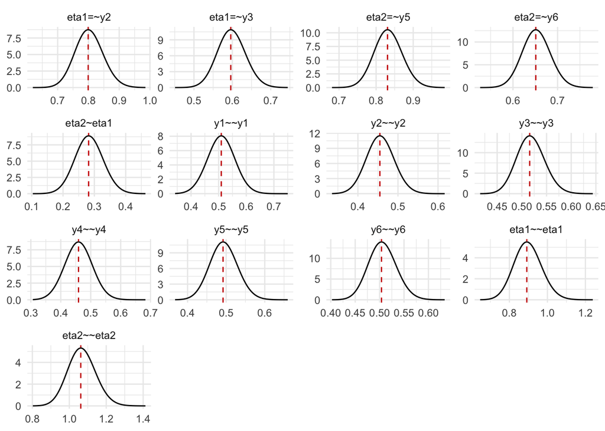

```r
plot(fit)
```

## Model comparison

In addition to several global fit indices (i.e. PPP, DIC), it is possible to compare models by way of Bayes factors using the `compare()` function. This function takes two `INLAvaan` objects and computes the Bayes factor using the Laplace approximations to the marginal likelihoods.

```r
mod2 <- "
  # A model with uncorrelated factors
  eta1 =~ y1 + y2 + y3
  eta2 =~ y4 + y5 + y6
  eta1 ~~ 0*eta2
"
fit2 <- asem(mod2, dat)
```

```
#> ℹ Mode finding and Hessian computation.
#> ✔ Posterior mode and Hessian. [37ms]
#>
#> ℹ Performing VB correction.
#> ✔ VB correction; mean |δ| = 0.040σ. [55ms]
#>
#> ⠙ Fitting 0/12 skew-normal marginals.
#> ✔ Fit 12/12 skew-normal marginals. [105ms]
#>
#> ⠙ Posterior sampling and summarising.
#> ✔ Summarise 1000 posterior draws. [162ms]
#>
#> ℹ Fit measures: PPP, DIC.
```

```r
compare(fit, fit2)
```

```
#> Bayesian Model Comparison (INLAvaan)
#> Models ordered by marginal log-likelihood
#>
#>  Model npar Marg.Loglik   logBF      DIC     pD
#>    fit   13   -8084.295   0.000 16063.28 13.072
#>   fit2   12   -8099.371 -15.076 16103.09 11.947
```

As a note, there have been several criticisms of the use of Bayes factors for model comparison, particularly in the context of SEMs (Tendeiro and Kiers 2019; Schad et al. 2023). Leave-one-out cross-validation (LOO, Vehtari et al. 2017) and the widely applicable information criterion (WAIC, Watanabe 2010) are popular alternatives which compare models on out-of-sample predictive accuracy instead; see Merkle et al. (2019) for their use with latent variable models. Both are implemented in `{INLAvaan}`. The functions `loo()` and `waic()` require neither refitting nor sampling: both are computed in closed form from the same Taylor expansion around the fit’s Laplace summary.

```r
loo(fit)
```

```
#> ── Leave-one-subject-out ──────────────────────── 1000 subjects, second-order ──
#>
#>          Estimate    SE
#> elpd_loo  -8021.9  54.1
#> p_loo        13.0   0.5
#> looic     16043.7 108.2
#>
#> ── Curvature check ─────────────────────────────────────────────────────────────
#>
#>   first-to-second-order gap         6.6
#>   pD/2 (trace)                      6.5
#>   excess over pD/2 (trace)        +1.2%
#>
#> ℹ The gap approaches pD/2 (trace) from above. A large excess says the
#>   second-order expansion has not settled over the sample.
```

To compare models on this predictive scale, pass `loo = TRUE` to `compare()`. Models are sorted by expected log predictive density (ELPD), with paired standard errors for the ELPD differences.

```r
compare(fit, fit2, loo = TRUE)
```

```
#> Bayesian Model Comparison (INLAvaan)
#> Models ordered by ELPD (Taylor LOO, second-order)
#> elpd_diff/se_diff are paired differences vs the best model
#>
#>  Model npar Marg.Loglik   logBF      DIC     pD      ELPD     SE  p_loo
#>    fit   13   -8084.295   0.000 16063.28 13.072 -8021.852 54.076 12.982
#>   fit2   12   -8099.371 -15.076 16103.09 11.947 -8041.958 54.306 12.090
#>  elpd_diff se_diff
#>      0.000   0.000
#>    -20.107   6.264
```

See the [cross-validation article](https://inlavaan.haziqj.ml/articles/loo.html) for the methodology and more advanced usage, including multigroup and two-level models, missing data, and scoring submodels without refitting.

## Setting priors

The `{INLAvaan}` package uses the same prior specification syntax as `{blavaan}` (Merkle and Rosseel 2018; Merkle et al. 2021), as detailed [here](https://blavaan.org/articles/prior.html). Essentially, there are two ways to set priors for model parameters: 1) Globally for all parameters of a certain type (e.g., all factor loadings, all regression coefficients, etc.); and 2) Individually for specific parameters in the model syntax.

The default global priors are similar to those from `{blavaan}`:

```r
priors_for()  # similar to blavaan::dpriors()
```

```
#>                nu             alpha            lambda              beta
#>    "normal(0,32)"    "normal(0,10)"    "normal(0,10)"    "normal(0,10)"
#>             theta               psi               rho               tau
#> "gamma(1,.5)[sd]" "gamma(1,.5)[sd]"       "beta(1,1)"   "normal(0,1.5)"
```

Note that, `{INLAvaan}` uses the separation strategy for variance matrices, and consequently places priors on **correlations** instead of *covariances*. If, instead we wished to set global priors, say a gamma distribution on **variances** instead of **standard deviations** (default), then we would do the following:

```r
DP <- priors_for(theta = "gamma(1,1)", psi = "gamma(1,1)")
DP
```

```
#>              nu           alpha          lambda            beta           theta
#>  "normal(0,32)"  "normal(0,10)"  "normal(0,10)"  "normal(0,10)"    "gamma(1,1)"
#>             psi             rho             tau
#>    "gamma(1,1)"     "beta(1,1)" "normal(0,1.5)"
```

```r
## fit <- asem(mod, dat, dpriors = DP)  # not run
```

To set individual priors for specific parameters, we can do so in the model syntax itself. For instance, to set a normal prior with mean 1 and standard deviation 3 for the factor loading of `y3` on `eta1`, and a normal prior with mean 0 and standard deviation 0.5 for the regression coefficient from `eta1` to `eta2`, we would specify the model as follows:

```r
mod <- "
  eta1 =~ y1 + y2 + prior('normal(1,3)')*y3
  eta2 =~ y4 + y5 + y6
  eta2 ~ prior('normal(0,.5)')*eta1
"
## fit <- asem(mod, dat)  # not run
```

## Dependency on R-INLA

Dependency on R-INLA has been temporarily removed for the current version of `{INLAvaan}` (>= 0.2.0). For a wide class LVMs and SEMs where the latent variables are unstructured and independent, the current implementation is sufficient. However, future versions of `{INLAvaan}` will re-introduce dependency on R-INLA to allow for more complex latent structures, such as spatial and temporal dependencies.

## References

Chiuchiolo, Cristian, Janet Van Niekerk, and Håvard Rue. 2023. “Joint Posterior Inference for Latent Gaussian Models with R-INLA.” *Journal of Statistical Computation and Simulation* 93 (5): 723–52. https://doi.org/10.1080/00949655.2022.2117813.

Gelman, Andrew, Xiao-Li Meng, and Hal Stern. 1996. “Posterior Predictive Assessment of Model Fitness Via Realized Discrepancies.” *Statistica Sinica* 6 (4): 733–60. https://www.jstor.org/stable/24306036.

Jamil, Haziq, and Håvard Rue. 2026a. *Approximate Bayesian Inference for Structural Equation Models Using Integrated Nested Laplace Approximations*. arXiv. https://doi.org/10.48550/arXiv.2603.25690.

Jamil, Haziq, and Håvard Rue. 2026b. *Implementation and Workflows for INLA-Based Approximate Bayesian Structural Equation Modelling*. arXiv. https://doi.org/10.48550/arXiv.2604.00671.

Martins, Thiago G., Daniel Simpson, Finn Lindgren, and Håvard Rue. 2013. “Bayesian Computing with INLA: New Features.” *Computational Statistics & Data Analysis* 67 (November): 68–83. https://doi.org/10.1016/j.csda.2013.04.014.

Merkle, Edgar C., Ellen Fitzsimmons, James Uanhoro, and Ben Goodrich. 2021. “Efficient Bayesian Structural Equation Modeling in Stan.” *Journal of Statistical Software* 100 (November): 1–22. https://doi.org/10.18637/jss.v100.i06.

Merkle, Edgar C., Daniel Furr, and Sophia Rabe-Hesketh. 2019. “Bayesian Comparison of Latent Variable Models: Conditional Versus Marginal Likelihoods.” *Psychometrika* 84 (3): 802–29. https://doi.org/10.1007/s11336-019-09679-0.

Merkle, Edgar C., and Yves Rosseel. 2018. “blavaan: Bayesian Structural Equation Models via Parameter Expansion.” *Journal of Statistical Software* 85 (June): 1–30. https://doi.org/10.18637/jss.v085.i04.

Rue, Håvard, Sara Martino, and Nicolas Chopin. 2009. “Approximate Bayesian Inference for Latent Gaussian Models by Using Integrated Nested Laplace Approximations.” *Journal of the Royal Statistical Society Series B: Statistical Methodology* 71 (2): 319–92. https://doi.org/10.1111/j.1467-9868.2008.00700.x.

Schad, Daniel J., Bruno Nicenboim, Paul-Christian Bürkner, Michael Betancourt, and Shravan Vasishth. 2023. “Workflow Techniques for the Robust Use of Bayes Factors.” *Psychological Methods* (US) 28 (6): 1404–26. https://doi.org/10.1037/met0000472.

Song, Xin‐Yuan, and Sik‐Yum Lee. 2012. *Basic and Advanced Bayesian Structural Equation Modeling: With Applications in the Medical and Behavioral Sciences*. 1st ed. Wiley Series in Probability and Statistics. Wiley. https://doi.org/10.1002/9781118358887.

Spiegelhalter, David J, Nicola G Best, Bradley P Carlin, and Angelika Van Der Linde. 2002. “Bayesian Measures of Model Complexity and Fit.” *Journal of the Royal Statistical Society Series B: Statistical Methodology* 64 (4): 583–639.

Tendeiro, Jorge N., and Henk A. L. Kiers. 2019. “A Review of Issues about Null Hypothesis Bayesian Testing.” *Psychological Methods* (US) 24 (6): 774–95. https://doi.org/10.1037/met0000221.

Tierney, Luke, Robert E. Kass, and Joseph B. Kadane. 1989. “Fully Exponential Laplace Approximations to Expectations and Variances of Nonpositive Functions.” *Journal of the American Statistical Association* 84 (407): 710–16. https://doi.org/10.1080/01621459.1989.10478824.

Vehtari, Aki, Andrew Gelman, and Jonah Gabry. 2017. “Practical Bayesian Model Evaluation Using Leave-One-Out Cross-Validation and WAIC.” *Statistics and Computing* 27 (5): 1413–32. https://doi.org/10.1007/s11222-016-9696-4.

Watanabe, Sumio. 2010. “Asymptotic Equivalence of Bayes Cross Validation and Widely Applicable Information Criterion in Singular Learning Theory.” *Journal of Machine Learning Research* 11: 3571–94.